# Automatic Flight Test Report

[figure not shown]

```python
import matplotlib.pyplot as plt
# Insert your logo into the generated images folder and re-write the directory below with your image name.
image = plt.imread("..\images\Your_logo_file_name_here.png")
_ = plt.figure(figsize=(20,8))
img = plt.imshow(image)
_ = plt.axis('off')
```

Flight No 1, 10/01/2019

*Below is the Required code, please run this code to allow other code to function*

```python
# GRAPH_DATA_IMPORT
import sys
import pickle as pk
import warnings

# Hides warnings
warnings.filterwarnings('ignore')

# Creates a link to where the code is stored.
sys.path.append("C:\\Users\\aw6g15\\University of Southampton\\Adrian Weishaeupl - Documents\\PhD\\2019\\AutoFLpy\\AutoFLpy\\autoflpy")
from autoflpy.util.flight_log_code import *
#Path to the compressed data.
data_file_path = "C:\\Users\\aw6g15\\University of Southampton\\Adrian Weishaeupl - Documents\\PhD\\2019\\AutoFLpy\\AutoFLpy\\autoflpy\\user_files\\excel_file_path\\20190110_Flight01.pkl"
# Uncompressing the data.
values_list = pk.load(open(data_file_path, "rb"))
print("Data imported")
```

```
Data imported
```

# Table of Contents

- METAR information
- Checklist information
- Graphs
  - GNSS altitude, signal strength and speed plotted against time
  - GNSS latitude and longitude
  - Flight computer battery voltage and current
  - Control inputs plotted against time
  - Air data aginst time
  - Flight attitude
  - Flight computer vibration data
  - Arduino temprature data
  - Arduino battery data
  - Autopilot data

# METAR Information

The METARs for EGHE were:

type: routine report, cycle 16 (automatic report) (manually corrected report)

time: Thu Jan 10 15:50:00 2019

wind: NW to NNE at 4 knots

visibility: greater than 10000 meters

sky: a few clouds at 800 feet

[output not shown]

METAR: COR EGHE 101550Z 02004KT 320V030 9999 FEW008 BKN020  
type: routine report, cycle 15 (automatic report)

time: Thu Jan 10 15:20:00 2019

temperature: 9.0 C

dew point: 5.0 C

wind: NNE at 3 knots

visibility: greater than 10000 meters

pressure: 1032.0 mb

sky: broken clouds at 2200 feet

METAR: EGHE 101520Z 03003KT 9999 BKN022 09/05 Q1032  
This METAR data was from:https://www.ogimet.com/display_metars2.php?lang=en&lugar=EGHE&tipo=ALL&ord=REV&nil=SI&fmt=html&ano=2019&mes=01&day=10&hora=15&anof=2019&mesf=01&dayf=10&horaf=15&minf=59&send=send

# Checklist Information

The Initial Pre-Flight, Launch and Post-Flight checklists were actioned.

The flight Duration was recorded as / can be found at: 5.0, this data was recorded by Adrian Weishaeupl.

The Initial Pre-Flight was actioned by Adrian Weishaeupl starting at 2019-01-10 15:31:44 and ending at 2019-01-10 15:32:58. The notes recorded on this checklist were: *THIS IS A TEST.* The Battery voltages of each battery are/ can be found at: *25.2.*

The Launch was actioned by Adrian Weishaeupl starting at 2019-01-10 15:33:05 and ending at 2019-01-10 15:33:46. The notes recorded on this checklist were: *TEST.*

The Post-Flight was actioned by Adrian Weishaeupl starting at 2019-01-10 15:33:48 and ending at 2019-01-10 15:34:23. The notes recorded on this checklist were: *TEST.*

The checklist version used was v0.1.

# Graphs

Below are the Graphs of the data recorded from the flight. For more information on how to manipulate these graphs and customise them, please visit https://autoflpy.readthedocs.io/en/latest/examples.html.

## GNSS altitude, signal strength and speed plotted against time

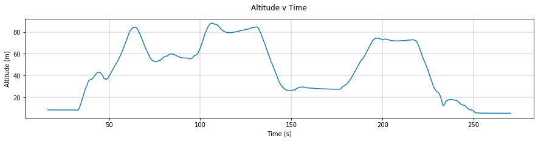

```python
x_limits=["x_min", "x_max"]
y_limits=["y_min", "y_max"]
graph_plotter([["y", "altitude", "gps"], ["x", "time", "gps"]], values_list, x_limits, y_limits)
```

Altitude - from the GPS data set. This is an altitude above ground level and is using the GNSS.

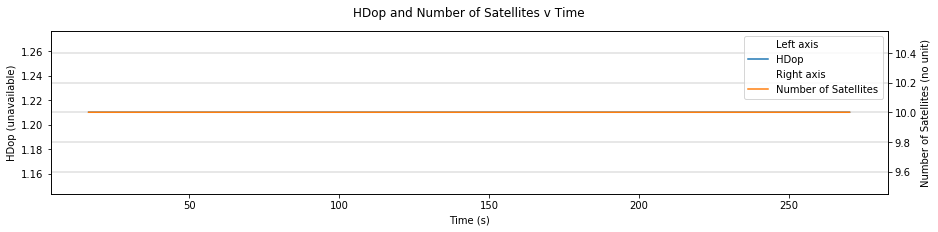

```python
x_limits=["x_min", "x_max"]
y_limits_left=["y_min", "y_max"]
y_limits_right=["y_min", "y_max"]
legend_location=1
multiaxis_graph_plotter([["y", "hdop", "gps"]], [["y", "number of satellites", "gps"], ["x", "time", "gps"]], values_list, x_limits, y_limits_left, y_limits_right, legend_location)
```

HDop - horizontal dilution of precision. HDOP is a factor in determining the relative accuracy of a horizontal position. The smaller the DOP number, the better the geometry.

Number of Satellites - The number of satellites whose signal is being received. The type of satellite network being used depends on you sensor.

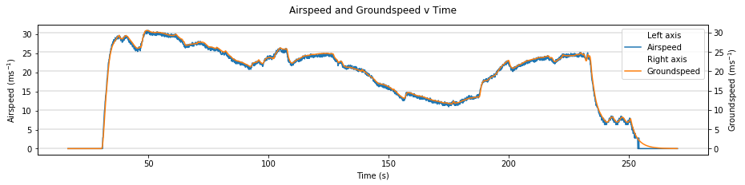

```python
x_limits=["x_min", "x_max"]
y_limits_left=["y_min", "y_max"]
y_limits_right=["y_min", "y_max"]
legend_location=1
multiaxis_graph_plotter([["y", "airspeed", "arsp"], ["x", "time", "arsp"]], [["y", "groundspeed", "gps"], ["x", "time", "gps"]], values_list, x_limits, y_limits_left, y_limits_right, legend_location)
```

Airspeed - the type of airspeed (IAS, TAS, CAS, EAS) depends on the sensor you are using.

Groundspeed - from the GPS data set. This is the speed travelled along the ground and is derived from GNSS measurements.

## GNSS latitude and longitude

```
Location does not have high resolution Stamen terrain map data. Defaulting to OpenStreetMap data.
```

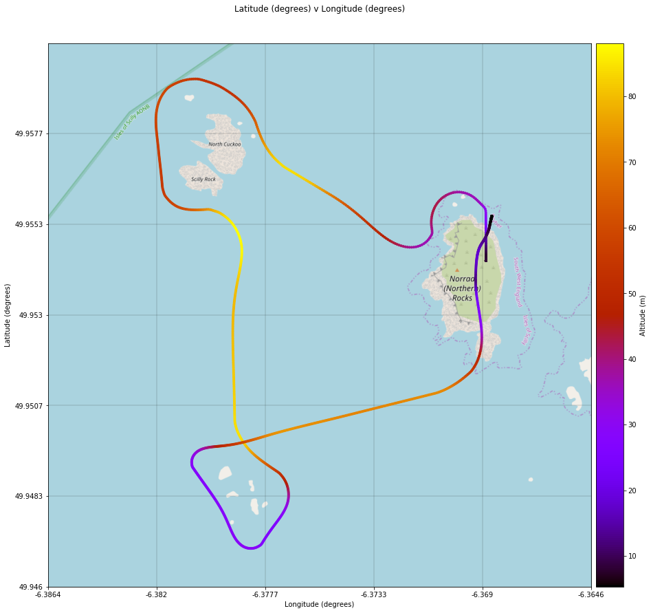

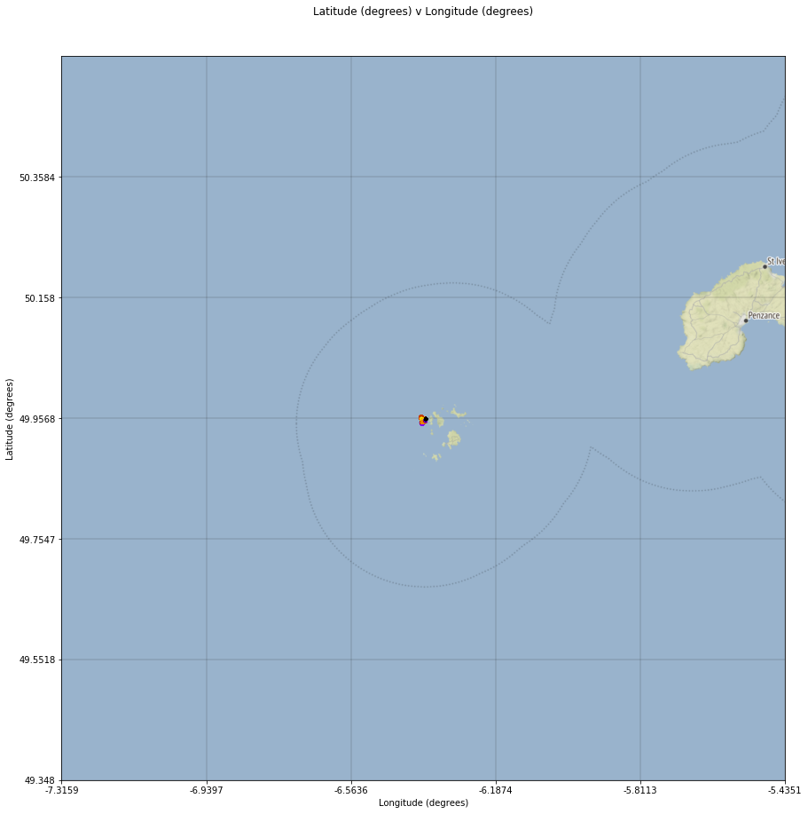

```python
x_limits=["x_min", "x_max"]
y_limits=["y_min", "y_max"]
graph_plotter([["y", "latitude", "gps"], ["x", "longitude", "gps"]], values_list, x_limits, y_limits)
```

Position data - from the GPS data set.

This is a completely fictitious, illustrative virtual flight and this example should in no way be seen as a suggestion of the suitability of the location for flight operations. All flights in UK airspace should be conducted in the framework set out by the Civil Aviation Authority.

## Flight computer battery voltage and current

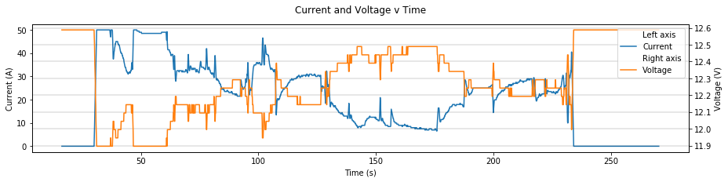

```python
x_limits=["x_min", "x_max"]
y_limits_left=["y_min", "y_max"]
y_limits_right=["y_min", "y_max"]
legend_location=1
multiaxis_graph_plotter([["y", "current", "bat"], ["x", "time", "bat"]], [["y", "voltage", "bat"], ["x", "time", "bat"]], values_list, x_limits, y_limits_left, y_limits_right, legend_location)
```

Battery voltage - as read by the power sensor.

Current - as read by the power sensor.

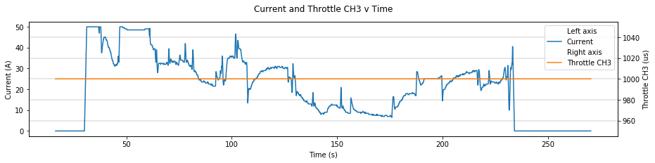

```python
x_limits=["x_min", "x_max"]
y_limits_left=["y_min", "y_max"]
y_limits_right=["y_min", "y_max"]
legend_location=1
multiaxis_graph_plotter([["y", "current", "bat"], ["x", "time", "bat"]], [["y", "throttle ch3", "rcin"], ["x", "time", "rcin"]], values_list, x_limits, y_limits_left, y_limits_right, legend_location)
```

## Control inputs plotted against time

The following variables are represented in micro seconds (us). This is a Pulse Width Modulation (PWM) signal which is a way of representing an analogue signal digitally. It is used in many applications such as servo motors.

NOTE: Channels may not be mapped in the same way as done here. To change the channel mapping and names, access the Name_converter_list.txt file and change the following names.

Example:

```
RCIN, C5, flap_CH5, us
```

to

```
RCIN, C5, throttle_CH5, us
```

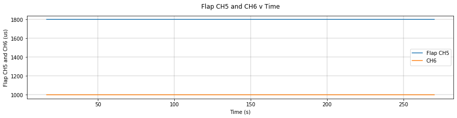

```python
x_limits=["x_min", "x_max"]
y_limits=["y_min", "y_max"]
graph_plotter([["x", "time", "rcin"], ["y", "flap ch5", "rcin"], ["y", "ch6", "rcin"]], values_list, x_limits, y_limits)
```

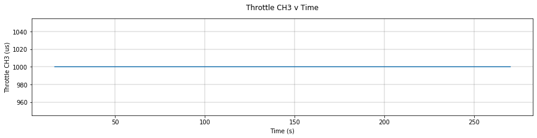

```python
x_limits=["x_min", "x_max"]
y_limits=["y_min", "y_max"]
graph_plotter([["x", "time", "rcin"], ["y", "throttle ch3", "rcin"]], values_list, x_limits, y_limits)
```

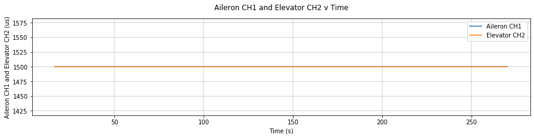

```python
x_limits=["x_min", "x_max"]
y_limits=["y_min", "y_max"]
graph_plotter([["x", "time", "rcin"], ["y", "aileron ch1", "rcin"], ["y", "elevator ch2", "rcin"], ["y", "rudder ch3", "rcin"]], values_list, x_limits, y_limits)
```

## Air data against time

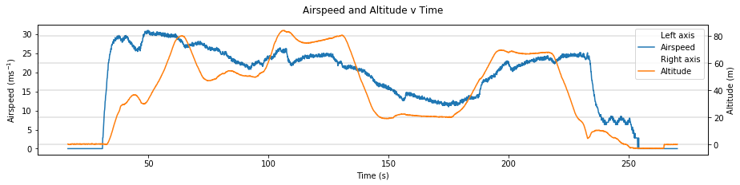

```python
x_limits=["x_min", "x_max"]
y_limits_left=["y_min", "y_max"]
y_limits_right=["y_min", "y_max"]
legend_location=1
multiaxis_graph_plotter([["y", "airspeed", "arsp"], ["x", "time", "arsp"]], [["y", "altitude", "baro"], ["x", "time", "baro"]], values_list, x_limits, y_limits_left, y_limits_right, legend_location)
```

Altitude - from the barometer data set. This is the altitude derived from the air pressure and is relative to the arming altitude.

Airspeed - the type of airspeed (IAS, TAS, CAS, EAS) depends on the sensor you are using.

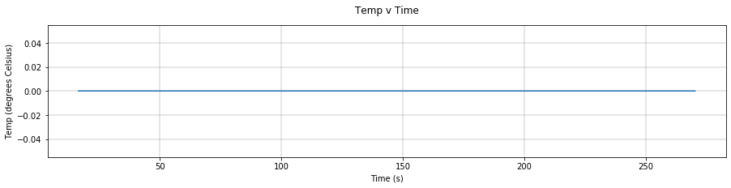

```python
x_limits=["x_min", "x_max"]
y_limits=["y_min", "y_max"]
graph_plotter([["y", "temp", "arsp"], ["x", "time", "arsp"]], values_list, x_limits, y_limits)
```

Temperature - measured by the airspeed sensor.

## Flight attitude

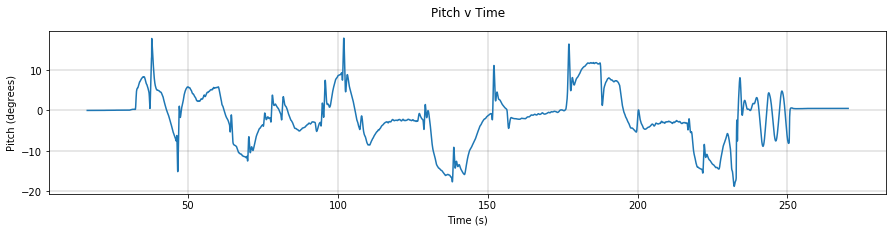

```python
x_limits=["x_min", "x_max"]
y_limits=["y_min", "y_max"]
graph_plotter([["y", "pitch", "ctun"], ["x", "time", "ctun"]], values_list, x_limits, y_limits)
```

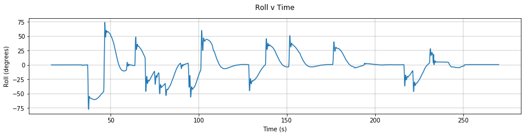

```python
x_limits=["x_min", "x_max"]
y_limits=["y_min", "y_max"]
graph_plotter([["y", "roll", "ctun"], ["x", "time", "ctun"]], values_list, x_limits, y_limits)
```

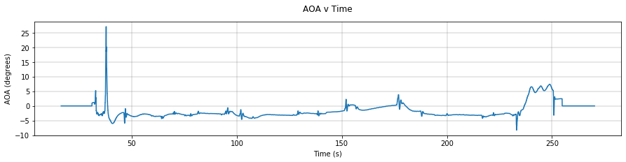

```python
x_limits=["x_min", "x_max"]
y_limits=["y_min", "y_max"]
graph_plotter([["y", "aoa", "aoa"], ["x", "time", "aoa"]], values_list, x_limits, y_limits)
```

AOA - Angle Of Attack. This is the angle between the incoming air and the aircraft's horizontal plane. It is a calculated measurement.

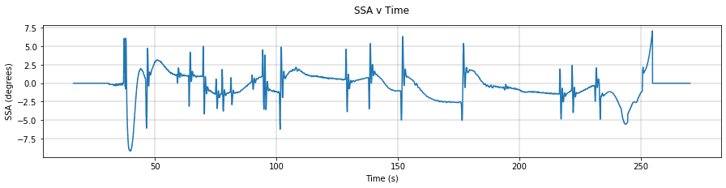

```python
x_limits=["x_min", "x_max"]
y_limits=["y_min", "y_max"]
graph_plotter([["y", "ssa", "aoa"], ["x", "time", "aoa"]], values_list, x_limits, y_limits)
```

SSA - Side Slip Angle. The angle between the incoming air and the aircraft's vertical plane. It is a calculated measurement.

## Flight computer vibration data

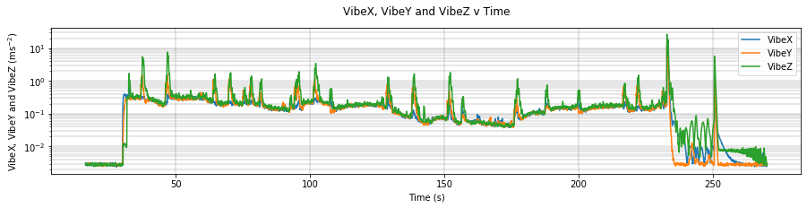

```python
x_limits=["x_min", "x_max"]
y_limits=["y_min", "y_max"]
graph_plotter([["x", "time", "vibe"], ["y", "vibex", "vibe"], ["y", "vibey", "vibe"], ["y", "vibez", "vibe"]], values_list, x_limits, y_limits)
```

## Arduino temprature data

The arduino data section serves to show the user how to add additional, non-flight computer related data to the report. In this example, the data is recorded by an arduino.

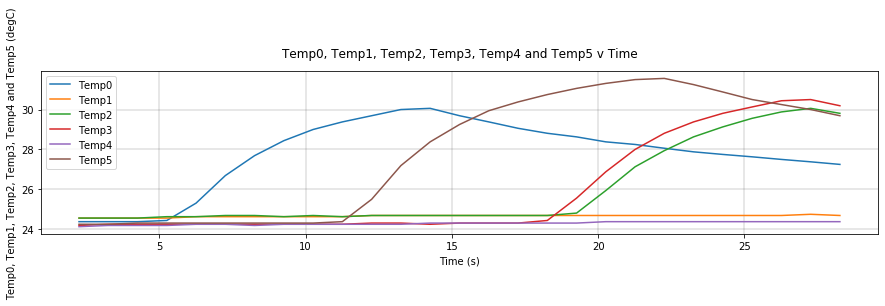

```python
x_limits=["x_min", "x_max"]
y_limits=["y_min", "y_max"]
graph_plotter([["x", "time", "arduinomicro"], ["y", "temp0", "arduinomicro"], ["y", "temp1", "arduinomicro"], ["y", "temp2", "arduinomicro"], ["y", "temp3", "arduinomicro"], ["y", "temp4", "arduinomicro"], ["y", "temp5", "arduinomicro"]], values_list, x_limits, y_limits)
```

The above graph shows some mock data of 6 additional temperature sensors plotted. These were recorded by an external arduino.

## Arduino battery data

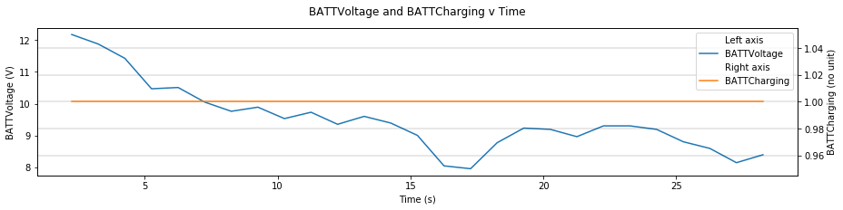

```python
x_limits=["x_min", "x_max"]
y_limits_left=["y_min", "y_max"]
y_limits_right=["y_min", "y_max"]
legend_location=1
multiaxis_graph_plotter([["y", "battvoltage", "arduinomicro"], ["x", "time", "arduinomicro"]], [["y", "battcharging", "arduinomicro"], ["x", "time", "arduinomicro"]], values_list, x_limits, y_limits_left, y_limits_right, legend_location)
```

The above data shows additional mock battery data recorded by an arduino. In this case, battvoltage represents the voltage of the external battery and battcharging is a binary representation of whether or not the battery is currently being charged.

## Autopilot data

The following section represents data about the autopilot's operation. The data can be understood through the following example:

desired_roll - the roll that the autopilot is instructing the aircraft to do.

roll - the roll that the aircraft is actually doing.

This data is useful for troubleshooting flight computer problems.

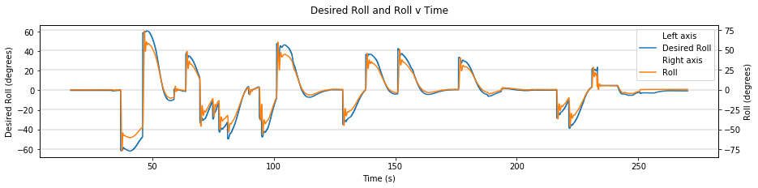

```python
x_limits=["x_min", "x_max"]
y_limits_left=["y_min", "y_max"]
y_limits_right=["y_min", "y_max"]
legend_location=1
multiaxis_graph_plotter([["y", "desired roll", "att"]], [["y", "roll", "att"], ["x", "time", "att"]], values_list, x_limits, y_limits_left, y_limits_right, legend_location)
```

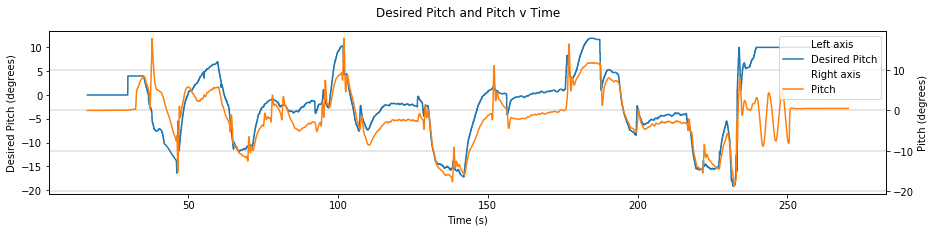

```python
x_limits=["x_min", "x_max"]
y_limits_left=["y_min", "y_max"]
y_limits_right=["y_min", "y_max"]
legend_location=1
multiaxis_graph_plotter([["y", "desired pitch", "att"]], [["y", "pitch", "att"], ["x", "time", "att"]], values_list, x_limits, y_limits_left, y_limits_right, legend_location)
```

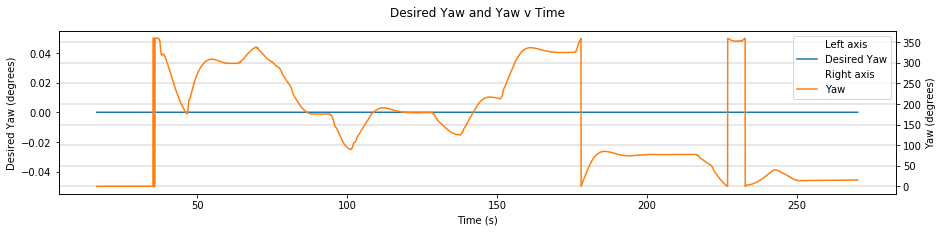

```python
x_limits=["x_min", "x_max"]
y_limits_left=["y_min", "y_max"]
y_limits_right=["y_min", "y_max"]
legend_location=1
multiaxis_graph_plotter([["y", "desired yaw", "att"]], [["y", "yaw", "att"], ["x", "time", "att"]], values_list, x_limits, y_limits_left, y_limits_right, legend_location)
```